# Production Costs 2

September 5, 2018

## Pregame

- Homeworks 1 & 2 are due Friday by 5pm.
- Extra tutoring through [ASCC](https://tutoring.ascc.wsu.edu/CampusTutoringList.aspx).
- Writing Assignments 1 and 2 are posted. Deadlines: 9/19/2018 and 10/10/2018.
- EXTRA EXTRA CREDIT: Attend the Soonish lecture on Wednesday, Sept 5, at 5 pm in CUE 203. Verify your attendance [here](https://commonreading.wsu.edu/event-attendance/) to get credit (5 points).

## Feedback

### Good:

- You look like Joseph Gordon-Levitt if he had long hair 👍👍.

### Needs improvement:

- Incorporate Joseph Gordon-Levitt in lectures.
- I know time is a matter but go deeper into the topic to make sure we all understand.

## I was going for this

[figure not shown]

## Not this

[figure not shown]

## Back to Productivity

[figure not shown]

| Labor | Number of Lattes | Marginal Productivity | Marginal Labor Cost | Labor Cost |
| --- | --- | --- | --- | --- |
| 1 | 300 | NA | 400 | 400 |
| 2 | 750 | 0.3 | 400 | 800 |
| 3 | 1500 | 0.5 | 400 | 1200 |
| 4 | 2100 | 0.4 | 400 | 1600 |
| 5 | 2550 | 0.3 | 400 | 2000 |
| 6 | 2850 | 0.2 | 400 | 2400 |
| 7 | 3000 | 0.1 | 400 | 2800 |

## Average Variable Cost

- **Average Variable Cost (AVC)** - *Total variable cost (TVC) divided by the total production. Variable costs consist of inputs that can be adjusted in the short term such as labor and supplies.*

E.g. if a college track team produces 4 star athletes per year and they have variable costs of $2.5 million, the average variable cost is

\[ \frac{TVC}{Q} = \frac{2.5}{4} = 625,000 \; \mbox{dollars.} \]

## Average Total Cost

- **Average Total Cost** - *Total cost divided by the total production. Total costs consist of the sum of total fixed costs and total variable costs.*

E.g. if the college track team has fixed costs of $1 million and variable costs of $2.5 million, the average total cost is

\[ \frac{TC}{Q} = \frac{1 + 2.5}{4} = 875,000 \; \mbox{dollars.} \]

## Marginal Cost

- **Marginal Cost** - *The additional cost of one more unit of output. Marginal cost is equal to the slop of the Total Cost Curve.*

E.g. Suppose the college wants to produce 5 star athletes per year. They estimate that the total cost would be $1.1 million in fixed costs and $3 million in variable costs. Then the *marginal cost* of the 5th star athlete is

\[ \frac{\Delta TC}{\Delta Q} = \frac{(1.1 + 3) - (1 + 2.5)}{5 - 4} = 600,000 \; \mbox{dollars.} \]

The new **Average Total Cost** would be

\[ \frac{TC}{Q} = \frac{1.1 + 3}{5} = 820,000 \; \mbox{dollars.} \]

*What does this imply about whether the college should increase their investment in star athletes?*

## Feeling Good?

[interactive chart not shown]

[via GIPHY](https://giphy.com/gifs/zooey-deschanel-500-days-of-summer-the-smiths-mZ6Qs0gLuEybe)

## Feeling Bad?

[interactive chart not shown]

[via GIPHY](https://giphy.com/gifs/break-joseph-gordon-levitt-500-days-of-summer-zUfUCj8ZLRczK)

## Graphing Costs

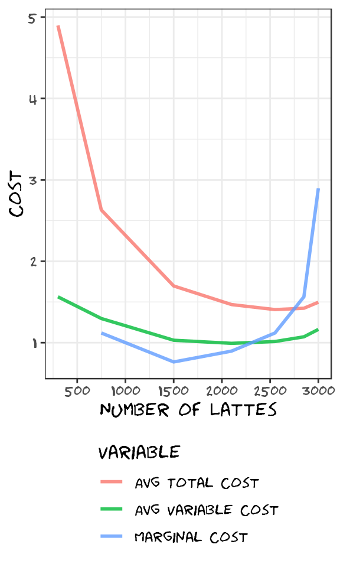

| Number of Lattes | Variable Cost | Fixed Cost | Avg Variable Cost | Avg Total Cost | Marginal Cost |
| --- | --- | --- | --- | --- | --- |
| 300 | 469 | 1000 | 1.6 | 4.9 | NA |
| 750 | 972 | 1000 | 1.3 | 2.6 | 1.1 |
| 1500 | 1545 | 1000 | 1 | 1.7 | 0.76 |
| 2100 | 2083 | 1000 | 0.99 | 1.5 | 0.9 |
| 2550 | 2586 | 1000 | 1 | 1.4 | 1.1 |
| 2850 | 3056 | 1000 | 1.1 | 1.4 | 1.6 |
| 3000 | 3490 | 1000 | 1.2 | 1.5 | 2.9 |

## Why is the ATC curve U-shaped?

- **Spreading Effect**: On the one hand, each additional output lowers average fixed costs (AFC), so the ATC is declining,
- **Diminishing Marginal Returns**: on the other, each additional unit faces diminishing marginal returns from labor, so the ATC is increasing.

*At low levels of production, the cost savings due to the spreading effect are higher so ATC declines overall, but at higher levels of production diminishing marginal returns have a stronger effect so the ATC increases again.*

## Graphing Costs

M is the minimum average total cost. (Why?)

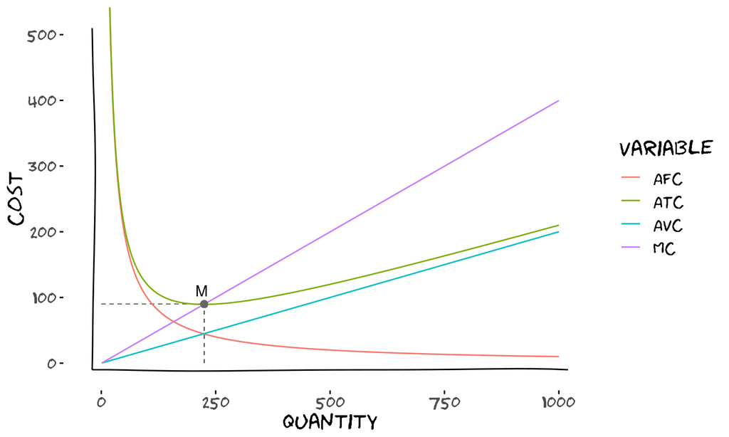

## An example: the banana stand

Let’s walk through this. Suppose we are 14 years old and our parents tell us

```
"there's always money in the banana stand."
```

## The banana stand

[interactive chart not shown]

[via GIPHY](https://giphy.com/gifs/arrested-development-television-angry-nkOqBHEJ1hcTm)

## Can we use child labor for our banana stand?

http://videos.criticalcommons.org/transcoded/http/www.criticalcommons.org/Members/JJWooten/clips/horrible-bosses-2-child-labor/video_file/mp4-high/horroble-bosses-2-child-labor-mp4.mp4?_=1

## The banana stand

- Building the banana stand costs $100.
- Bananas cost $0.49 per pound.
- Child labor (our friends) costs $40 per day per worker
- Cutting bananas has diminishing returns to scale (i.e. as we increase the amount of labor, the number of bananas each person can cut goes down – the *marginal productivity* of each additional worker is smaller than that of the worker before them.)

*Let’s put this in a spreadsheet!*

## The banana stand

[interactive chart not shown]

[via GIPHY](https://giphy.com/gifs/christmas-december-elf-6f6HMJ2iGNLyM)

## The banana stand

- [Google sheet of banana stand costs](https://docs.google.com/spreadsheets/d/1RfWQVQwJTbVr5A5AtMoBFPsJ2bb5dZALEFjoEiLWFtI/edit?usp=sharing)

## A tutorial with spreadsheets

- Khan Academy tutorial on costs using a spreadsheet: https://www.youtube.com/watch?v=bBQVaRnHqLs

## Wrapping Up

- Complete the [knowledge check](https://goo.gl/forms/xVcayjE8zNCsYgtz1) for today’s participation point.
- Please provide [feedback](https://goo.gl/forms/8SiOwdi19kN8cINJ3) on today’s lecture.